# Basics of statistical analysis in R for neurochemists

#### More advanced way how to visualize the data using ggplot2 package

ggplot is a standard package used to visualize data in R. It provides much nicer aesthetics and more customisation than the base R functions like plot, barplot or boxplot. Let’s reproduce some of our previous plots in ggplot.

ggplot works in layers and layers are stacked on top of each other using + sign

```
## No summary function supplied, defaulting to `mean_se()`
```

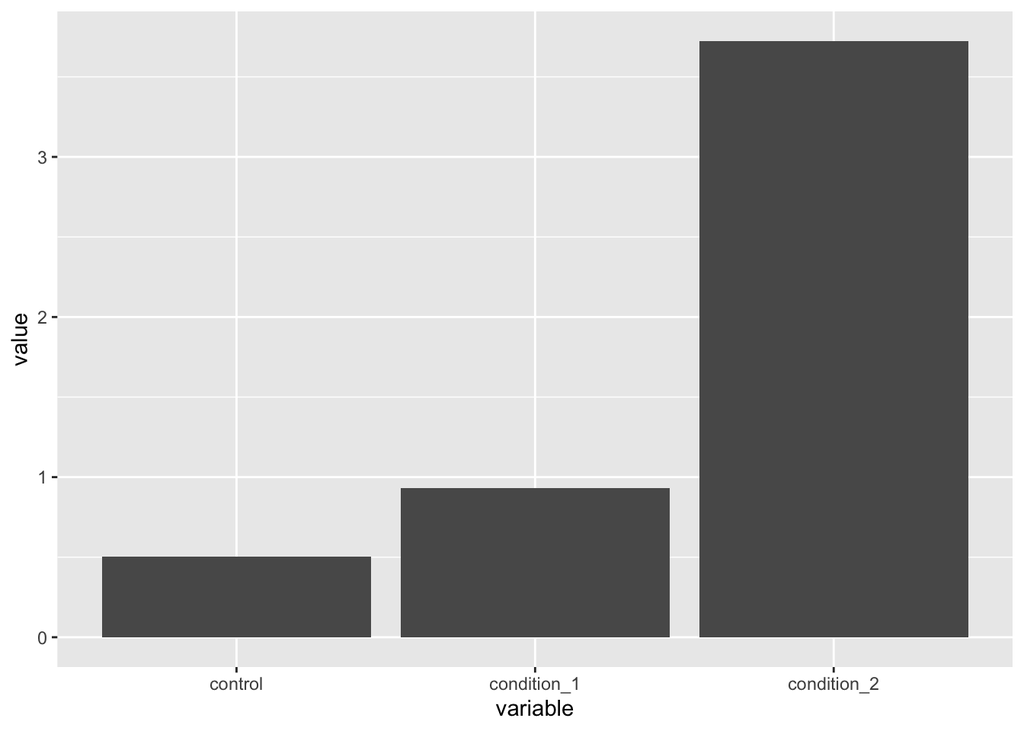

```r
library(ggplot2)
library(ggridges)
library(ggthemes)

# ggplot always uses long format for plotting
ggplot(data = neurites.long) + geom_bar(aes(x=variable,y=value), stat='summary',fun.y='mean')
```

```
## No summary function supplied, defaulting to `mean_se()`
```

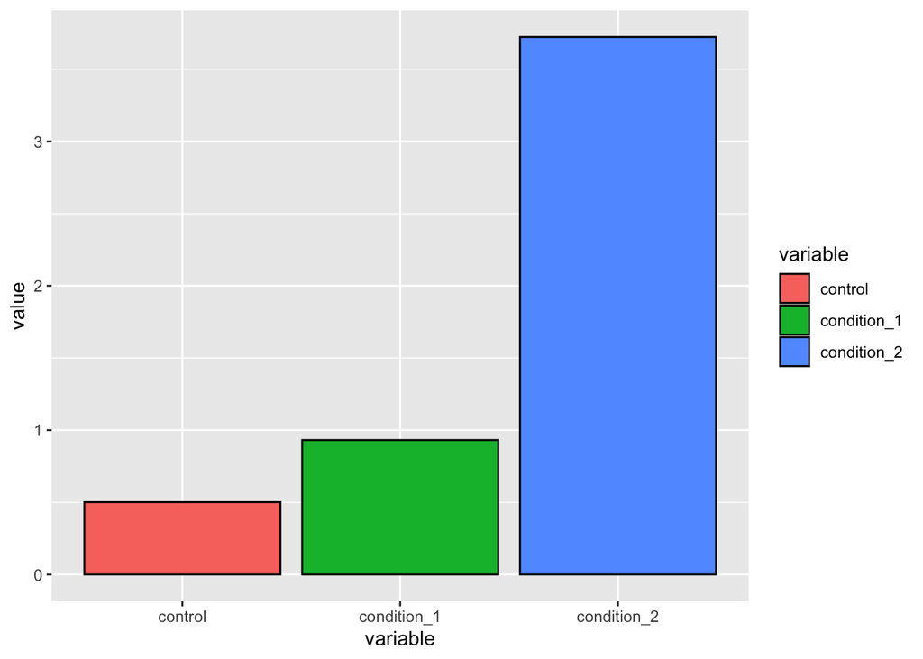

```r
# ggplot(data=) == initializes a ggplot object
# geom_bar adds a layer with barplot
# stat=summary tells it to use summary statistics and fun.y tells it to use mean as functon to calculate summary statistics
# aes() contains information about what should be on x and y axes

# Let's add some color to the plot
ggplot(data = neurites.long) + geom_bar(aes(x=variable,y=value,fill=variable), stat='summary',fun.y='mean',col='black')
```

```
## No summary function supplied, defaulting to `mean_se()`
```

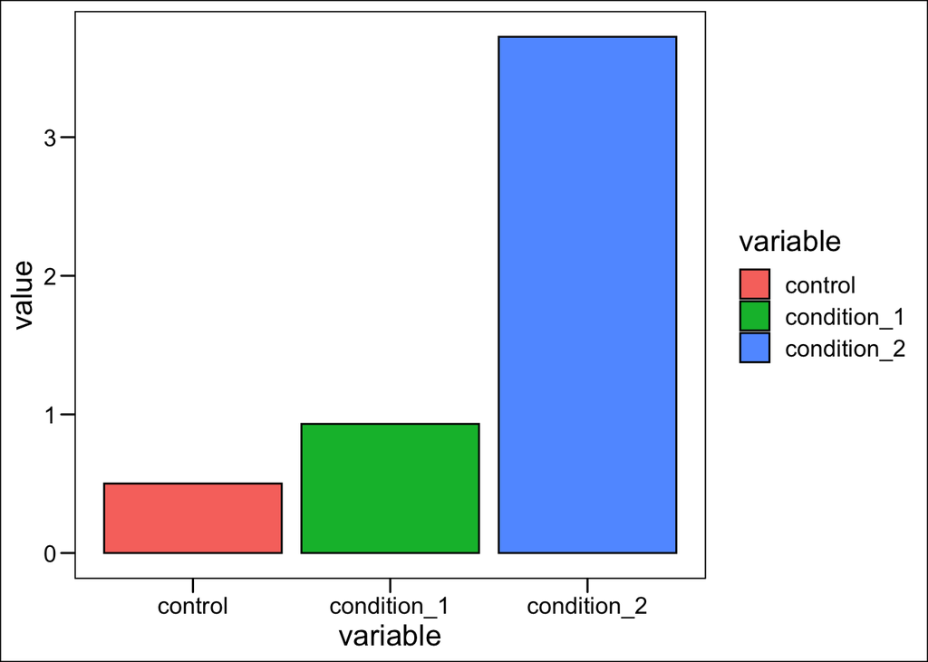

```r
# We can also easily change the theme of the plot by adding theme layer - theme_base() makes it look more like a base R plot
ggplot(data = neurites.long) + geom_bar(aes(x=variable,y=value,fill=variable), stat='summary',fun.y='mean',col='black') + theme_base()
```

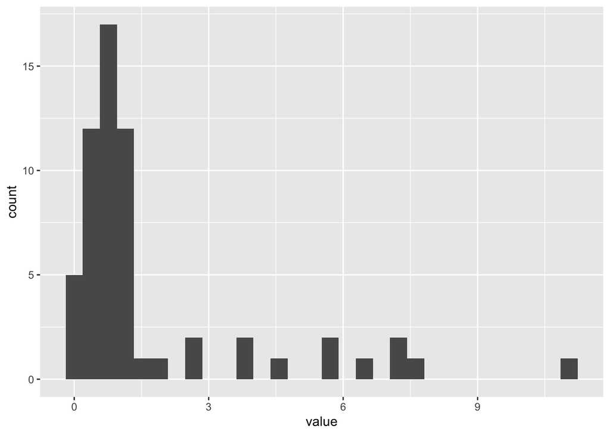

```r
# Let's plot histogram in ggplot - this histogram ignores the information about the variable. It just pools our control, and conditions into a single graph
ggplot(data=neurites.long) + geom_histogram(aes(x=value))
```

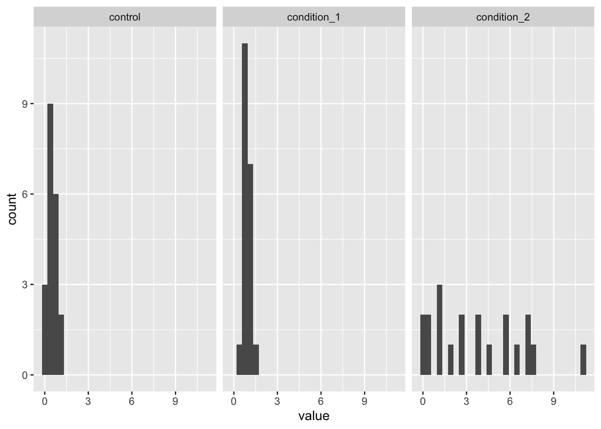

```r
# To split the histograms into 3 different ones, we can use facet_wrap layer to split the plots
ggplot(data=neurites.long) + geom_histogram(aes(x=value)) + facet_wrap(~variable)
```

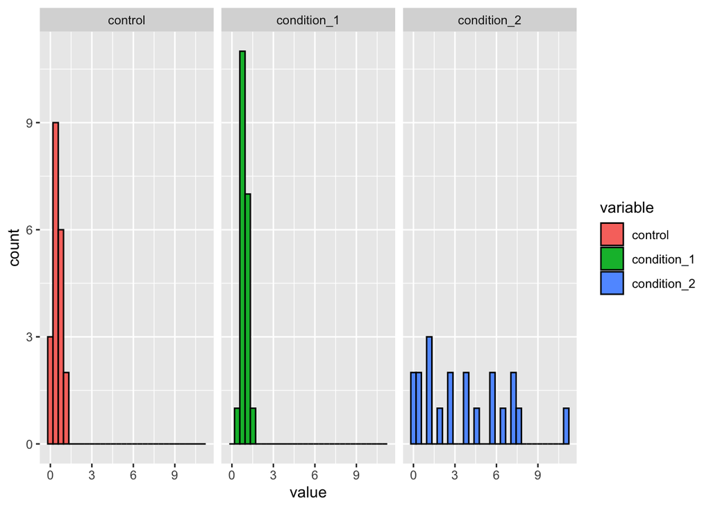

```r
# Let's add some color again
ggplot(data=neurites.long) + geom_histogram(aes(x=value,fill=variable),col='black') + facet_wrap(~variable) # Creates 3 histograms for our 3 variables
```

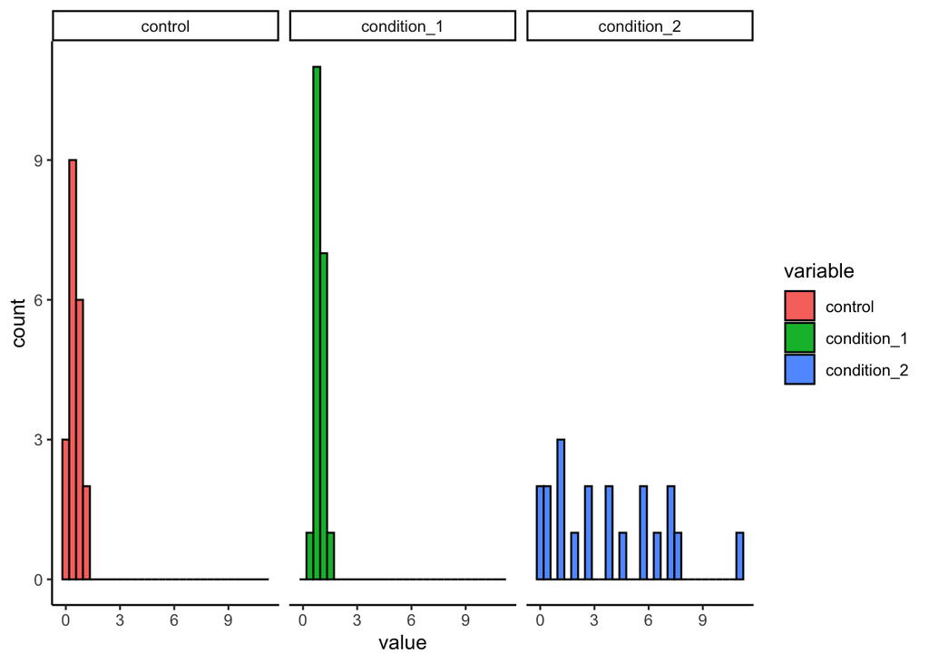

```r
# And change the theme
ggplot(data=neurites.long) + geom_histogram(aes(x=value,fill=variable),col='black') + facet_wrap(~variable) + theme_classic()
```

Let’s create a boxplot in ggplot

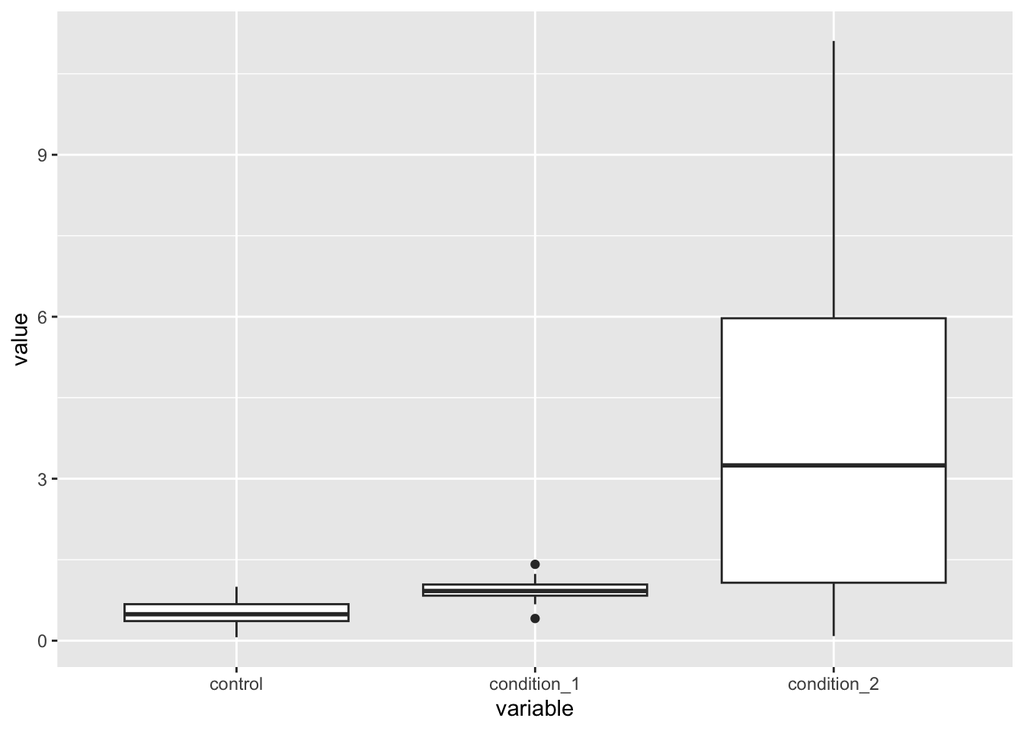

```r
# Basic boxplot
ggplot(data=neurites.long) + geom_boxplot(aes(x=variable,y=value))
```

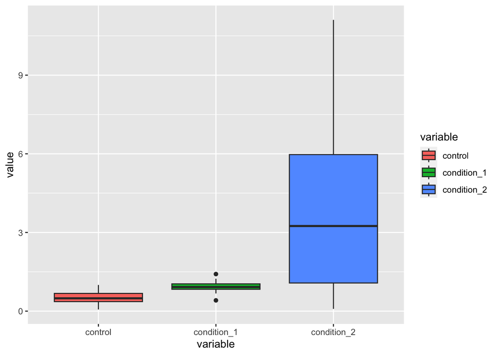

```r
# Add some color
ggplot(data=neurites.long) + geom_boxplot(aes(x=variable,y=value,fill=variable))
```

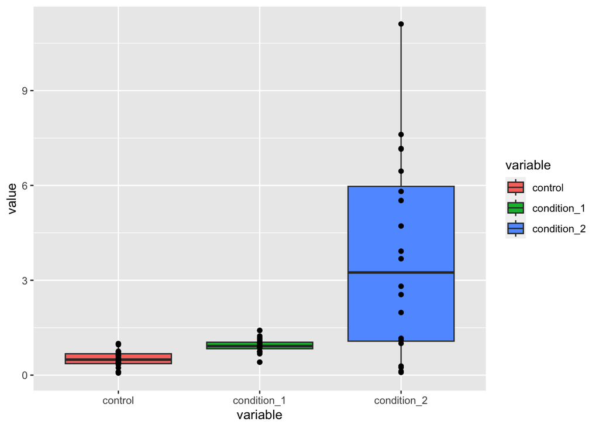

```r
# Because of layer based syntax we can stack layers on top of each other
# Let's add individual datapoints to the boxplot
ggplot(data=neurites.long) + geom_boxplot(aes(x=variable,y=value,fill=variable)) + geom_point(aes(x=variable,y=value))
```

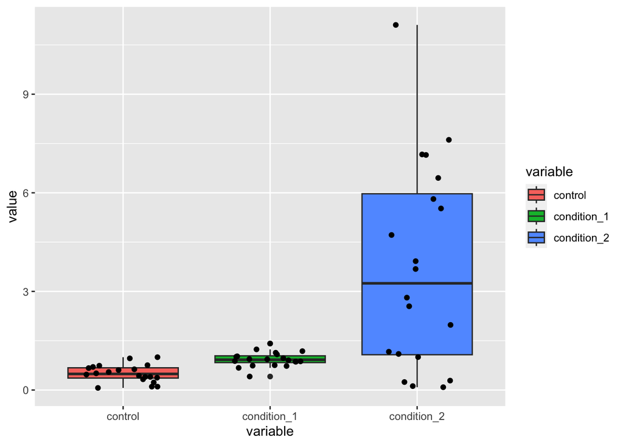

```r
# The points are all in one row, we can add some jitter to avoid overplotting
ggplot(data=neurites.long) + geom_boxplot(aes(x=variable,y=value,fill=variable)) + geom_jitter(aes(x=variable,y=value),width = 0.25)
```

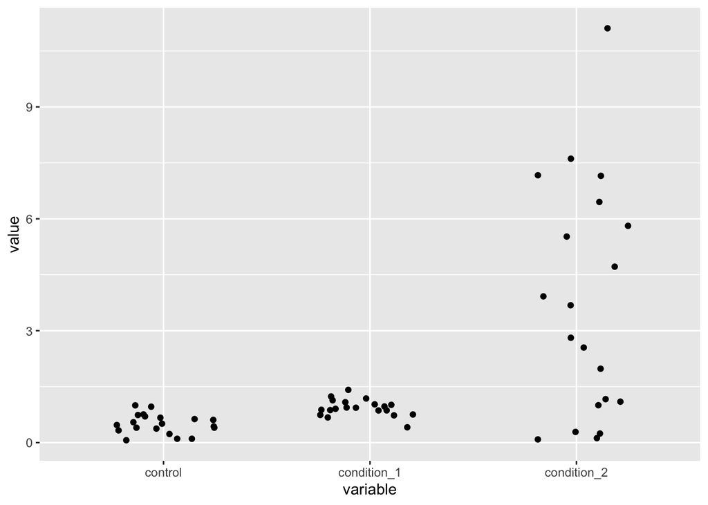

```r
# If we skip the boxplot, we can just have a jitter plot
ggplot(data=neurites.long) +  geom_jitter(aes(x=variable,y=value),width = 0.25)
```

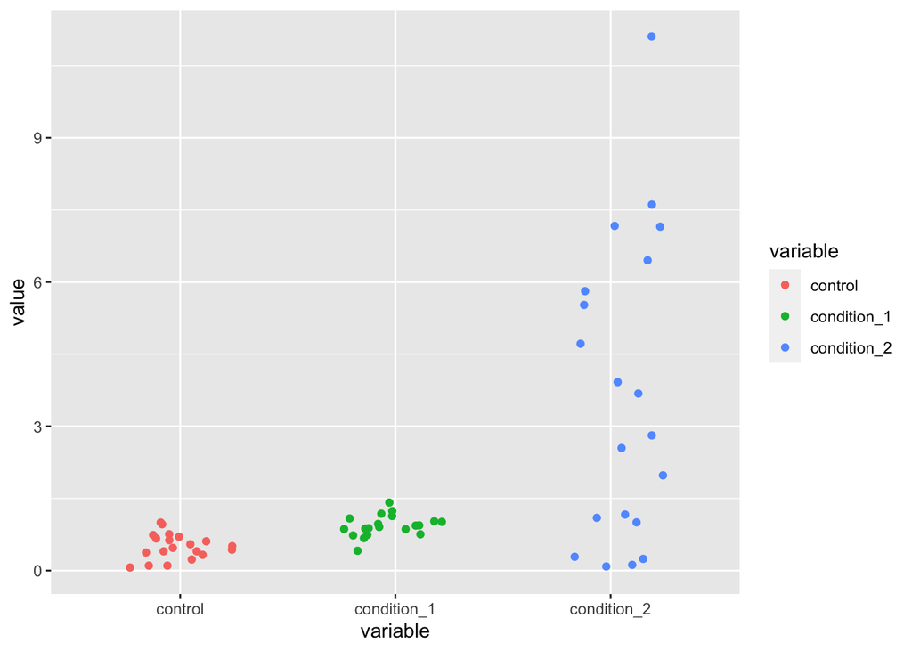

```r
# And with some colors
ggplot(data=neurites.long) +  geom_jitter(aes(x=variable,y=value,col=variable),width = 0.25)
```

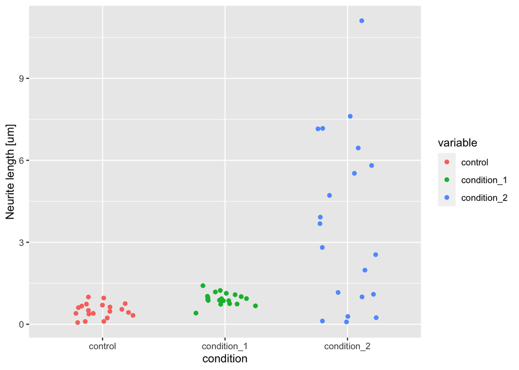

```r
# Let's now fix  some axis labels
ggplot(data=neurites.long) +  geom_jitter(aes(x=variable,y=value,col=variable),width = 0.25) + xlab("condition") + ylab("Neurite length [um]")
```

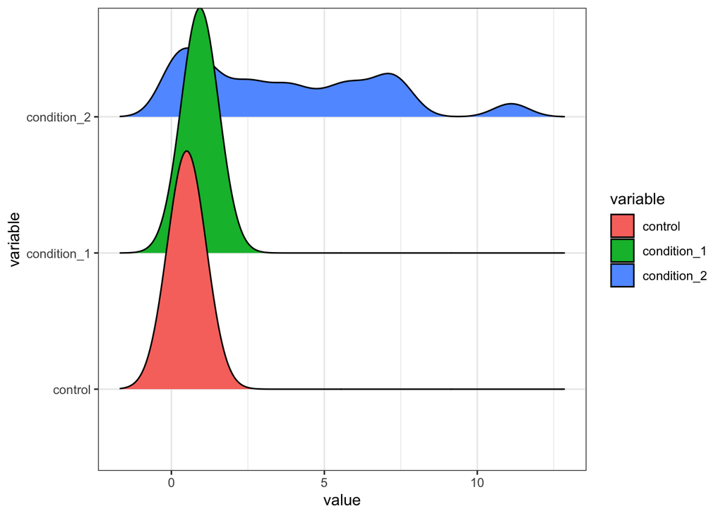

```r
# Density ridge histogram
ggplot(data=neurites.long) + geom_density_ridges(aes(x=value,y=variable,fill=variable)) + theme_bw()
```

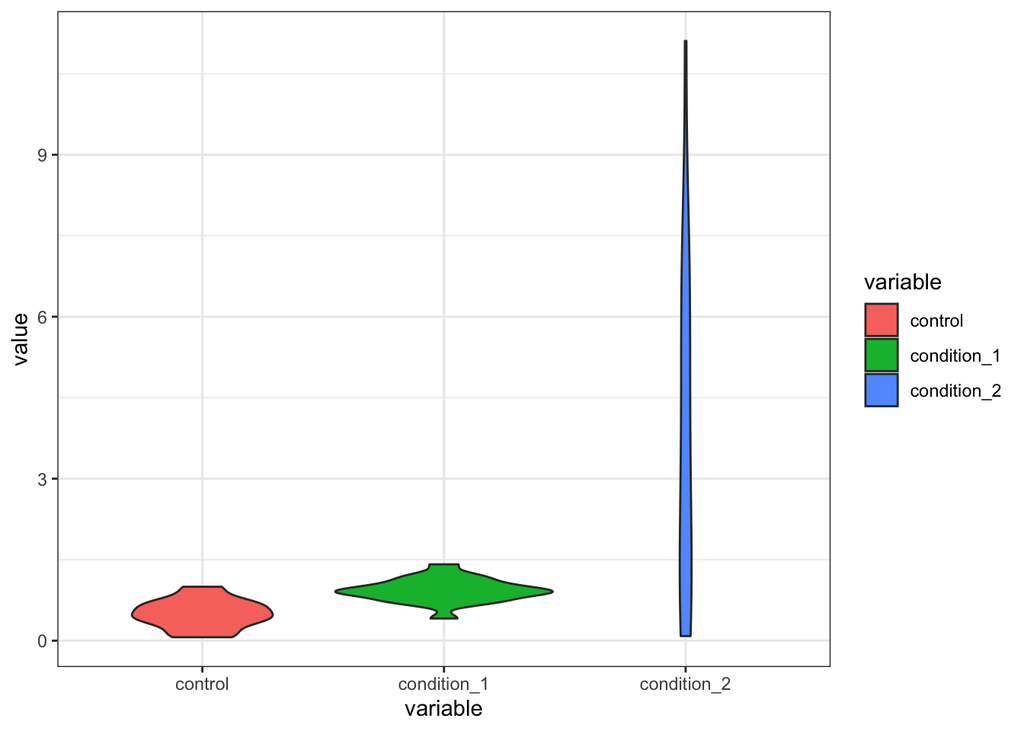

```r
# Violin plot
ggplot(data = neurites.long) + geom_violin(aes(y=value,x=variable,fill=variable)) + theme_bw()
```

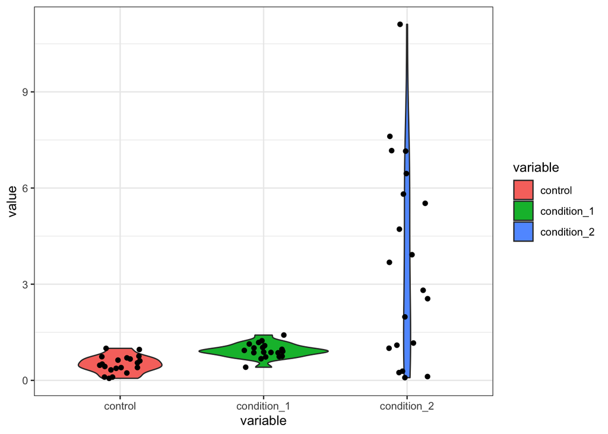

```r
# With dots
ggplot(data = neurites.long) + geom_violin(aes(y=value,x=variable,fill=variable)) + geom_jitter(aes(x=variable,y=value),width=0.15) + theme_bw()
```

## Task 3: Which statistical test should I use to compare the groups ?

### Is my data normally distributed ?

Many statistical tests, especially parametric tests like the t-test, ANOVA, and linear regression, assume that the data follows a normal distribution. These tests rely on the properties of the normal distribution to calculate probabilities and critical values

### 1. Visual inspection

We can plot histogram of the data using function hist()

```r
neurites
```

| control | condition_1 | condition_2 |
| --- | --- | --- |
| 0.06372999 | 0.7305269 | 1.09728997 |
| 0.10308265 | 1.1828578 | 3.92038951 |
| 0.99902660 | 0.7414197 | 5.52390681 |
| 0.60876101 | 0.6742225 | 7.15188387 |
| 0.63159041 | 1.0256576 | 7.16780066 |
| 0.39914599 | 1.4141315 | 7.61176463 |
| 0.70256457 | 0.9060978 | 6.45179316 |
| 0.10291603 | 0.8720033 | 0.08549482 |
| 0.73953168 | 0.4106907 | 0.24295711 |
| 0.32652134 | 1.0834832 | 1.00254557 |

[output cut: 10 more lines]

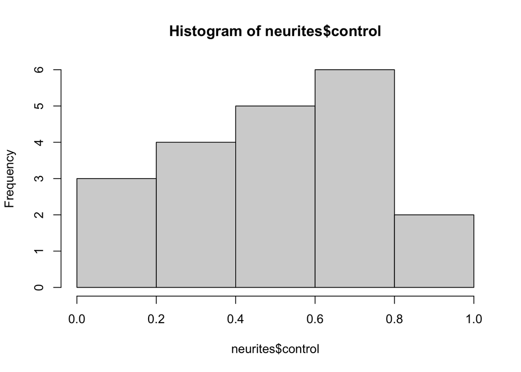

```r
hist(neurites$control)
```

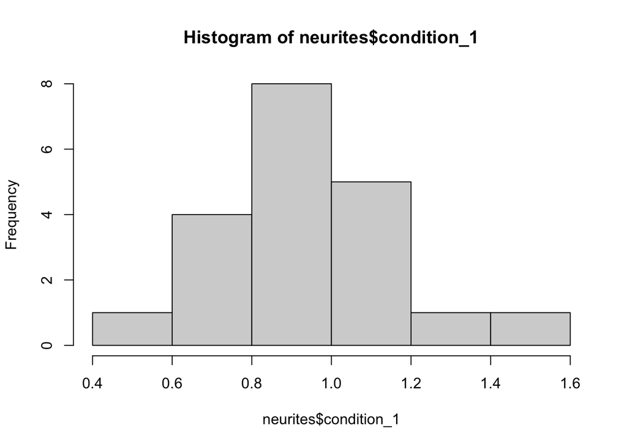

```r
hist(neurites$condition_1)
```

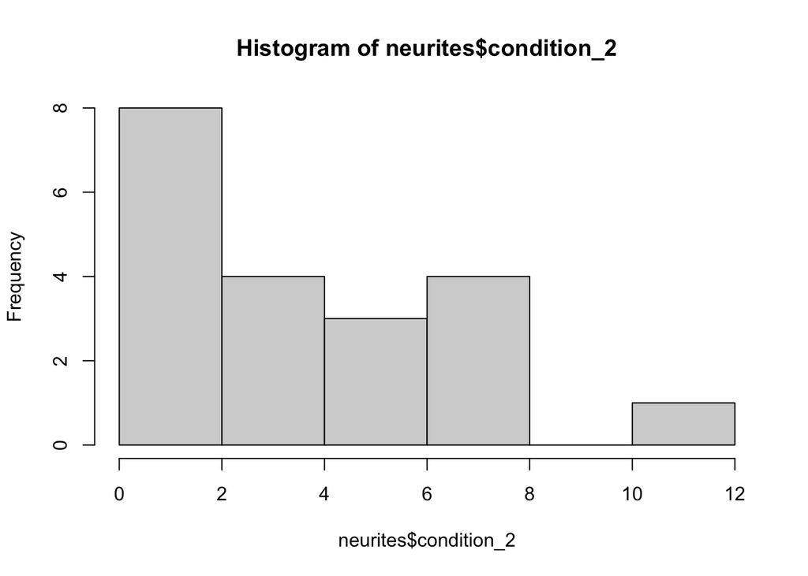

```r
hist(neurites$condition_2,breaks=5)
```

##### *Exercise 3 : Function histogram() uses parameter ‘breaks=’ to specify the numbers of bins to plot. Experiment with changing this parameter and see if you can get nicer looking histogram*

### QQ plot

Q-Q plots (quantile-quantile plots) are useful way how to estimate normality of a data

The data is first fitted with normal distribution, and then compared to observed data.

If the data is normally distributed all the data points should be exactly on the fitted line

For more details on qqplot see here: [link](http://www.sthda.com/english/wiki/qq-plots-quantile-quantile-plots-r-base-graphs)

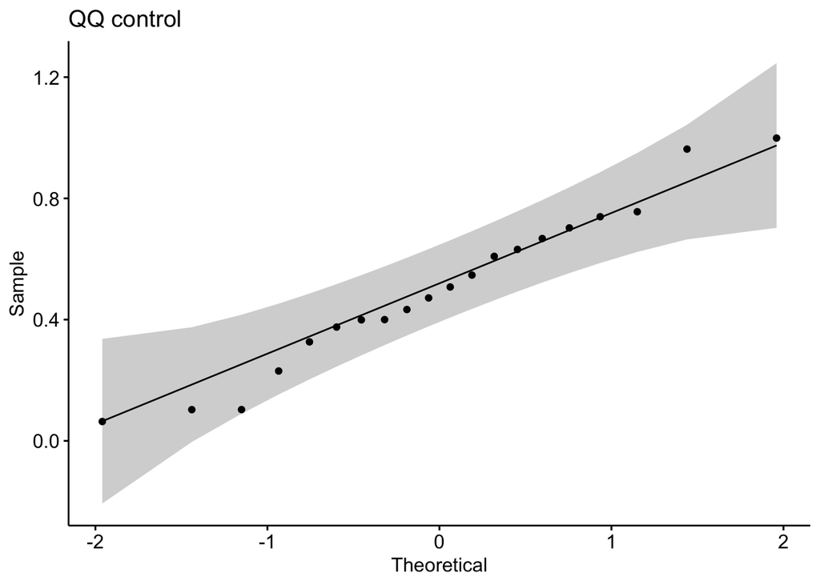

```r
library(ggpubr)
ggqqplot(neurites$control,title = 'QQ control')
```

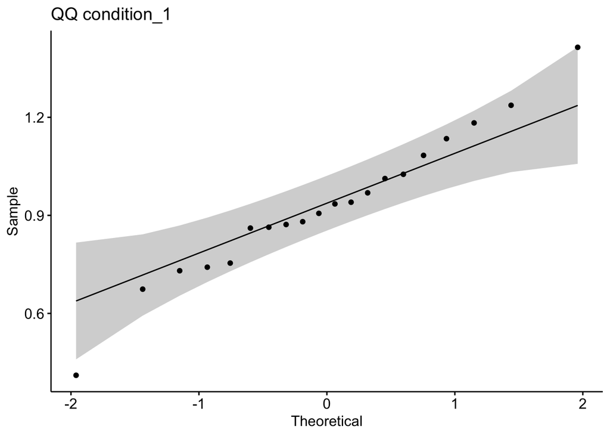

```r
ggqqplot(neurites$condition_1,title = 'QQ condition_1')
```

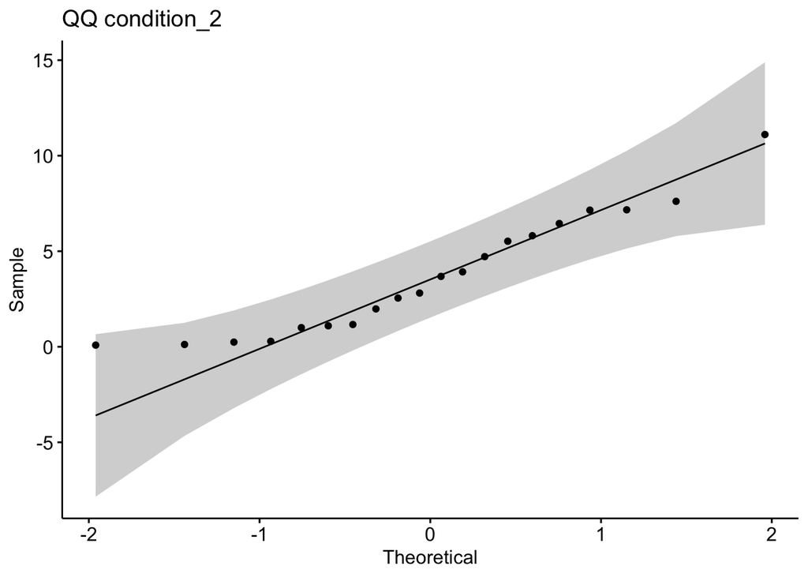

```r
ggqqplot(neurites$condition_2,title = 'QQ condition_2')
```

### Numerical methods

If the data is normaly distributed median and mean of the measurements should be vey close to each other

Let’s calculate the median and mean of our data

##### *Exercise 4 : Calculate and compare median and mean for each column of our dataset neurites*

Hint: Use functions median() and mean()

### Shapiro test of normality

There are several methods for normality test such as Kolmogorov-Smirnov (K-S) normality test and Shapiro-Wilk’s test.

Shapiro-Wilk’s method is widely recommended for normality test and it provides better power than K-S. It is based on the correlation between the data and the corresponding normal scores.

For more details on shapiro test see here [link](http://www.sthda.com/english/wiki/normality-test-in-r)

```r
shapiro.test(neurites$control)
```

```
##
##  Shapiro-Wilk normality test
##
## data:  neurites$control
## W = 0.97049, p-value = 0.7652
```

```r
shapiro.test(neurites$condition_1)
```

```
##
##  Shapiro-Wilk normality test
##
## data:  neurites$condition_1
## W = 0.9803, p-value = 0.9379
```

```r
shapiro.test(neurites$condition_2)
```

```
##
##  Shapiro-Wilk normality test
##
## data:  neurites$condition_2
## W = 0.92259, p-value = 0.1111
```

##### *Exercise 5 : Discuss: Is the data normaly distributed ?

### Example of **not** normally distributed data

If we merge several normal distributions we typically don’t get normally distributed data. We can look at such example by mixing the data from our 3 conditions together

```r
# Merge the data from all columns into single vector
mixed.data <- unname(unlist(neurites))
head(mixed.data)
```

```
## [1] 0.06372999 0.10308265 0.99902660 0.60876101 0.63159041 0.39914599
```

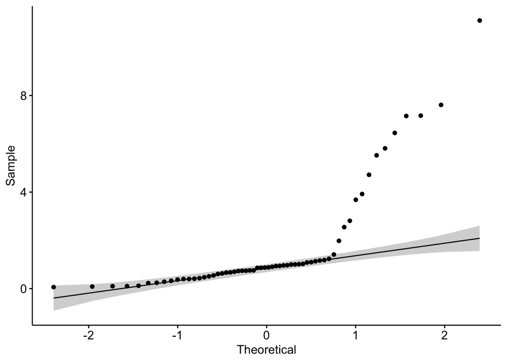

```r
# QQ-plot and shapiro test for all data merged together
ggqqplot(mixed.data)
```

```r
shapiro.test(mixed.data)
```

```
##
##  Shapiro-Wilk normality test
##
## data:  mixed.data
## W = 0.64966, p-value = 1.066e-10
```

### F test to compare sample variance

Comparing two variances is useful in several cases, including:

- When you want to perform a two samples t-test to check the equality of the variances of the two samples
- When you want to compare the variability of a new measurement method to an old one. Does the new method reduce the variability of the measure?

```r
# To check the equality of variance between our conditions in a pairwise manner do the following:
var.test(neurites$control,neurites$condition_1)
```

```
##
##  F test to compare two variances
##
## data:  neurites$control and neurites$condition_1
## F = 1.4325, num df = 19, denom df = 19, p-value = 0.4406
## alternative hypothesis: true ratio of variances is not equal to 1
## 95 percent confidence interval:
##  0.5670153 3.6192325
## sample estimates:
## ratio of variances
##           1.432536
```

```r
var.test(neurites$control,neurites$condition_2)
```

```
##
##  F test to compare two variances
##
## data:  neurites$control and neurites$condition_2
## F = 0.007197, num df = 19, denom df = 19, p-value = 3.68e-16
## alternative hypothesis: true ratio of variances is not equal to 1
## 95 percent confidence interval:
##  0.002848664 0.018182894
## sample estimates:
## ratio of variances
##         0.00719701
```

```r
var.test(neurites$condition_1,neurites$condition_2)
```

```
##
##  F test to compare two variances
##
## data:  neurites$condition_1 and neurites$condition_2
## F = 0.005024, num df = 19, denom df = 19, p-value < 2.2e-16
## alternative hypothesis: true ratio of variances is not equal to 1
## 95 percent confidence interval:
##  0.001988546 0.012692799
## sample estimates:
## ratio of variances
##        0.005023964
```

##### *Exercise 6: Answer the following questions:*

In summary our dataset contains samples with:

Choose one:

- Normal distribution
- Not normal distribution

Choose one:

- Equal variance
- Not equal variance

In order to perform statistical hypothesis testing, which test should we use ? (Choose one)

- Student’s t-test
- Kolmogorovov-Smirnov test (K-S test)
- Welch t-test
- ANOVA

### Perform single t.test of 2 conditions

We use function t.test(). Use parameter var.equal to set if there is equal variance between the two samples

T.test with unequal variance is also called Welch t-test

```r
test_1vs2 <- t.test(neurites$control, neurites$condition_1,var.equal = TRUE)
test_1vs2
```

```
##
##  Two Sample t-test
##
## data:  neurites$control and neurites$condition_1
## t = -5.5659, df = 38, p-value = 2.243e-06
## alternative hypothesis: true difference in means is not equal to 0
## 95 percent confidence interval:
##  -0.5864028 -0.2736052
## sample estimates:
## mean of x mean of y
## 0.5014132 0.9314173
```

```r
test_1vs2$p.value
```

```
## [1] 2.242894e-06
```

#### Exercise 7: Perform t-test to obtain p-value for condition_2 vs control

#### Exercise 8: Compare fold change (of mean) between condition_1 vs control and condition_2 vs control

Which of the comparisons has lower p-value ? What is the fold change between the samples (advanced: What is the log2 of fold change) ? Which treatment shows higher effect on neurite outgrowth ? What can you tell about variability between the treatments ?